# Chapter 5: Dimensionality reduction

## PCA of the dataset

PCA transforms the dataset into a new space. The dimensions of this new space are called the principal components of data. The first principal component captures the maximum amount of variance from the features of original data. Each suggessive principal component is orthogonal to the first (and other) components, and captures the maximum amount of variance left.

First we use the dataset as is and perform principal component analysis of it.

```r
pca_human <- prcomp(human)
summary(pca_human)
```

```
## Importance of components:
##                              PC1      PC2   PC3   PC4   PC5   PC6    PC7
## Standard deviation     1.854e+04 185.5219 25.19 11.45 3.766 1.566 0.1912
## Proportion of Variance 9.999e-01   0.0001  0.00  0.00 0.000 0.000 0.0000
## Cumulative Proportion  9.999e-01   1.0000  1.00  1.00 1.000 1.000 1.0000
##                           PC8
## Standard deviation     0.1591
## Proportion of Variance 0.0000
## Cumulative Proportion  1.0000
```

As we already see from the model summary, the first principal component PC1 captures almost all of the variance in the data by itself. Let’s plot the biplot to inspect the model visually.

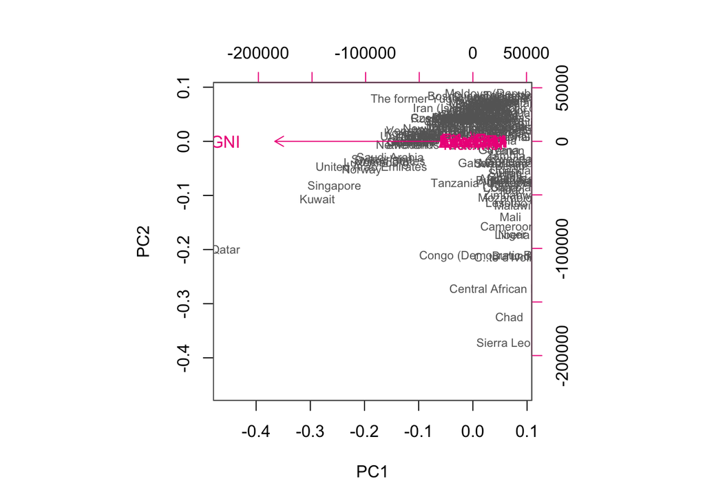

```r
biplot(pca_human, choices = 1:2, cex=c(0.7, 1), col = c("grey40", "deeppink2"))
```

We see from the biplot that the first principal componen, PC1, is practically identical to the `GNI` feature. The `GNI` arrow is much longer than the other arrows, reflecting its standard deviation. This is due to the variance of the `GNI` variable being really high compared to the other variables. Therefore, PCA ends up just explainen the variance of the data by the variance of `GNI`.

## PCA of the standardised dataset

Since PCA for the original data did not provide very good results, we’ll sandardise the dataset so that the variances are equal.

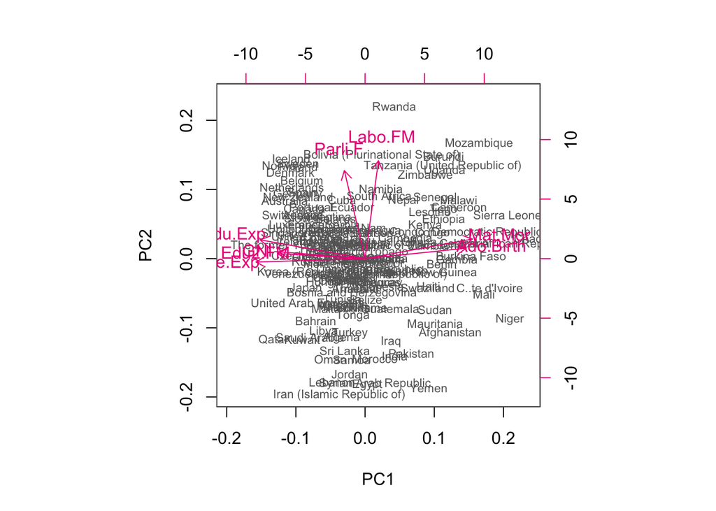

```r
human_std <- scale(human)
pca_human_std <- prcomp(human_std)
biplot(pca_human_std, choices = 1:2, cex=c(0.7, 1), col = c("grey40", "deeppink2"))
```

These PCA results are clearly different from the results of PCA on non-standardized dataset: GNI does not dominate the variance anymore, and the results make much more “sense”.

Interpreting the results of PCA from the bilplot, we see that

- Low values of PC1 describe countries with high expected years of schooling, high life expectancy, high female education compared to male education, and high GNI. Simultaneously, high values of PC1 describe countries with high maternal mortality ratio and high adolescent birth rate. The PC1 feature, then, could be interpreted to describe “inverse of standard of living”.
- High values of PC2 describe countries with high proportion of females in labor force compared to males, and hih percentage of females in parliament. The PC2 feature, then, could be interpreted to describe “Gender equality in society”.

These interpretations of PC and PC2 are, of course, rough descriptions of much more nuanced societal phenomena.

## Tea data

For the remaining part of the exercise we’ll use the tea dataset from FactoMineR.

```r
library(FactoMineR)
data(tea)
str(tea)
```

```
## 'data.frame':    300 obs. of  36 variables:
##  $ breakfast       : Factor w/ 2 levels "breakfast","Not.breakfast": 1 1 2 2 1 2 1 2 1 1 ...
##  $ tea.time        : Factor w/ 2 levels "Not.tea time",..: 1 1 2 1 1 1 2 2 2 1 ...
##  $ evening         : Factor w/ 2 levels "evening","Not.evening": 2 2 1 2 1 2 2 1 2 1 ...
##  $ lunch           : Factor w/ 2 levels "lunch","Not.lunch": 2 2 2 2 2 2 2 2 2 2 ...
##  $ dinner          : Factor w/ 2 levels "dinner","Not.dinner": 2 2 1 1 2 1 2 2 2 2 ...
##  $ always          : Factor w/ 2 levels "always","Not.always": 2 2 2 2 1 2 2 2 2 2 ...
##  $ home            : Factor w/ 2 levels "home","Not.home": 1 1 1 1 1 1 1 1 1 1 ...
##  $ work            : Factor w/ 2 levels "Not.work","work": 1 1 2 1 1 1 1 1 1 1 ...
##  $ tearoom         : Factor w/ 2 levels "Not.tearoom",..: 1 1 1 1 1 1 1 1 1 2 ...
##  $ friends         : Factor w/ 2 levels "friends","Not.friends": 2 2 1 2 2 2 1 2 2 2 ...
##  $ resto           : Factor w/ 2 levels "Not.resto","resto": 1 1 2 1 1 1 1 1 1 1 ...
##  $ pub             : Factor w/ 2 levels "Not.pub","pub": 1 1 1 1 1 1 1 1 1 1 ...
##  $ Tea             : Factor w/ 3 levels "black","Earl Grey",..: 1 1 2 2 2 2 2 1 2 1 ...
##  $ How             : Factor w/ 4 levels "alone","lemon",..: 1 3 1 1 1 1 1 3 3 1 ...
```

[output cut: 22 more lines]

The tea data has 300 observations of 36 variables. We’ll pick some variables that seem interesting (places to drink tea, gender, and age groups) and visualise only these variables.

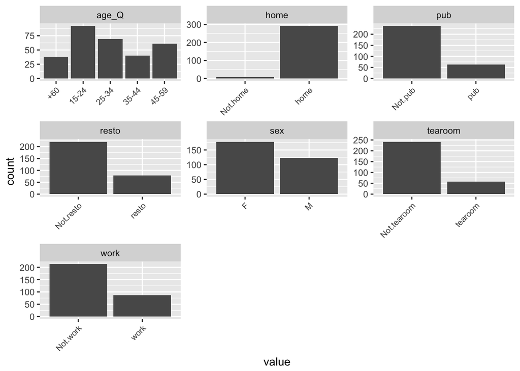

```r
library(tidyr)
keep <- c("home", "work", "tearoom", "resto", "pub", "age_Q", "sex")
tea_ <- dplyr::select(tea, one_of(keep))

gather(tea_) %>% ggplot(aes(value)) + facet_wrap("key", scales = "free") + geom_bar() + theme(axis.text.x = element_text(angle = 45, hjust = 1, size = 8))
```

We’ll also perform MCA for these variables.

```r
tea_mca <- MCA(tea_, graph = FALSE)
summary(tea_mca)
```

```
##
## Call:
## MCA(X = tea_, graph = FALSE)
##
##
## Eigenvalues
##                        Dim.1   Dim.2   Dim.3   Dim.4   Dim.5   Dim.6
## Variance               0.223   0.198   0.168   0.159   0.151   0.128
## % of var.             15.607  13.877  11.736  11.152  10.600   8.933
## Cumulative % of var.  15.607  29.484  41.220  52.372  62.971  71.905
##                        Dim.7   Dim.8   Dim.9  Dim.10
## Variance               0.115   0.103   0.097   0.087
## % of var.              8.028   7.198   6.769   6.100
## Cumulative % of var.  79.933  87.131  93.900 100.000
##
## Individuals (the 10 first)
##                Dim.1    ctr   cos2    Dim.2    ctr   cos2    Dim.3    ctr
## 1           | -0.403  0.243  0.123 |  0.128  0.028  0.012 | -0.319  0.203
## 2           | -0.219  0.071  0.057 | -0.250  0.105  0.074 | -0.127  0.032
## 3           |  0.509  0.388  0.175 |  0.262  0.116  0.046 | -0.145  0.042
## 4           | -0.545  0.443  0.413 | -0.172  0.050  0.041 | -0.167  0.055
## 5           | -0.498  0.370  0.259 |  0.094  0.015  0.009 | -0.049  0.005
## 6           | -0.545  0.443  0.413 | -0.172  0.050  0.041 | -0.167  0.055
## 7           | -0.403  0.243  0.123 |  0.128  0.028  0.012 | -0.319  0.203
## 8           | -0.124  0.023  0.013 | -0.216  0.079  0.039 | -0.398  0.315
## 9           | -0.403  0.243  0.123 |  0.128  0.028  0.012 | -0.319  0.203
## 10          |  0.081  0.010  0.003 |  0.066  0.007  0.002 | -0.027  0.001
##               cos2
## 1            0.077 |
## 2            0.019 |
## 3            0.014 |
## 4            0.039 |
## 5            0.003 |
## 6            0.039 |
## 7            0.077 |
## 8            0.131 |
## 9            0.077 |
## 10           0.000 |
##
## Categories (the 10 first)
```

[output cut: 17 more lines]

```
## tearoom      -1.318 |   0.676   7.532   0.110   5.724 |
## Not.resto    -5.345 |  -0.241   3.647   0.163  -6.972 |
## resto         5.345 |   0.674  10.203   0.163   6.972 |
## Not.pub       3.567 |  -0.034   0.076   0.004  -1.128 |
## pub          -3.567 |   0.126   0.286   0.004   1.128 |
##
## Categorical variables (eta2)
##               Dim.1 Dim.2 Dim.3
## home        | 0.001 0.167 0.049 |
## work        | 0.282 0.165 0.192 |
## tearoom     | 0.399 0.006 0.110 |
## resto       | 0.296 0.096 0.163 |
## pub         | 0.302 0.043 0.004 |
## age_Q       | 0.076 0.633 0.644 |
## sex         | 0.205 0.278 0.012 |
```

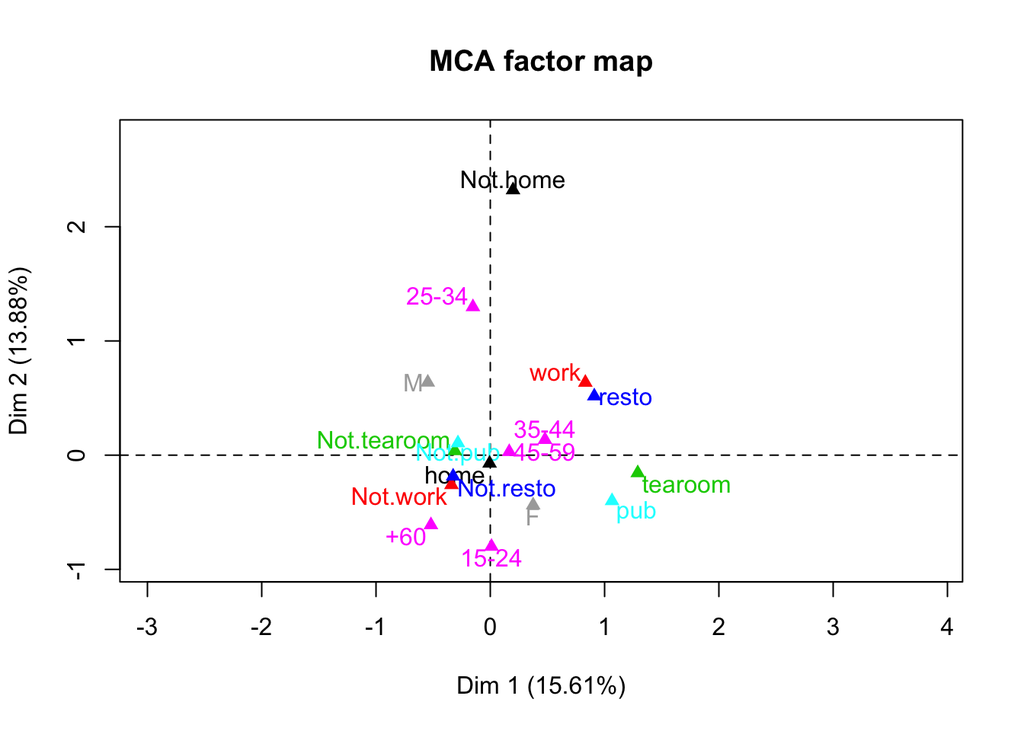

```r
plot(tea_mca, invisible=c("ind"), habillage = "quali")
```

The first two dimensions of MCA explain about 30% of variance.

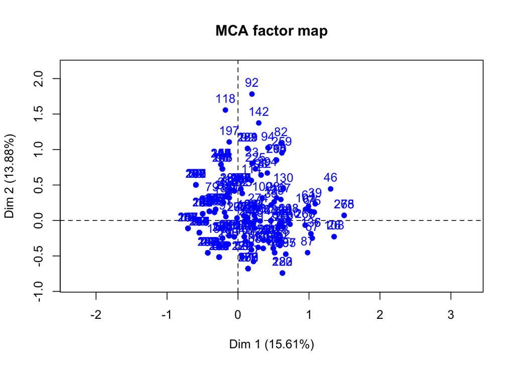

```r
plot(tea_mca, invisible=c("var"), habillage = "quali")
```

The biplot for individuals mostly shows that it is pretty hard to interpret. We mainly see that there are a few outlier individuals. This might indicate that the MCA result is to some extent dependent on these outliers.